# Data visualization with ggplot2

Author

Affiliation

Rosa Karlić

Bioinformatics group

## **Tidy Data**

Tidy data makes the analysis easier to do, faster to check, easier to plot and to reuse for other analysis. If you have a messy dataset and you think that it is exactly what you need, you will most likely use it only once - for one analysis and a single graph.

```
1. Each variable forms a column.

2. Each observation forms a row.

3. Each type of observational unit forms a table.
```

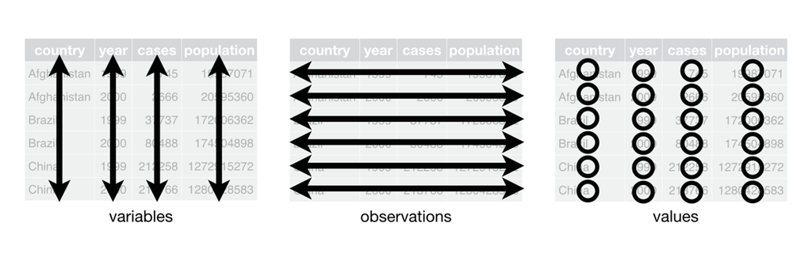

Fig1. Rules that make data tidy

### Tidy data vs. messy data

Examples of messy and tidy datasets (based on a dataset of TB cases in different countries).

| country | cases_1999 | cases_2000 | population_1999 | population_2000 |
| --- | --- | --- | --- | --- |
| Afghanistan | 745 | 2666 | 19987071 | 20595360 |
| Brazil | 37737 | 80488 | 172006362 | 174504898 |
| China | 212258 | 213766 | 1272915272 | 1280428583 |

Fig2. Messy data

| country | year | cases | population |
| --- | --- | --- | --- |
| Afghanistan | 1999 | 745 | 19987071 |
| Afghanistan | 2000 | 2666 | 20595360 |
| Brazil | 1999 | 37737 | 172006362 |
| Brazil | 2000 | 80488 | 174504898 |
| China | 1999 | 212258 | 1272915272 |
| China | 2000 | 213766 | 1280428583 |

Fig3. Tidy data

Advantages of using tidy data:

1. Consistent data structure makes it easier to learn the tools that work with it because they have an underlying uniformity.
2. Placing variables in columns makes use of R’s vectorization (functions and operations automatically apply element-wise to entire vectors).

   For more information see [Chapter 5: Data tidying](https://r4ds.hadley.nz/data-tidy.html) from

   Grolemund, G., Çetinkaya-Rundel, M., & Wickham, H. (2023). R for Data Science (2nd ed.). O’Reilly Media.

### Tidyverse

- Coherent system of packages for data manipulation, exploration and visualization that share a common design philosophy
- Mostly developed by Hadley Wickham
- https://www.tidyverse.org/

More information: [What is the tidyverse](https://rviews.rstudio.com/2017/06/08/what-is-the-tidyverse/)

### Data tidying - example

This dataset represents simulated qPCR (quantitative PCR) results used to measure gene expression differences between a control group and a treatment group over a 24-hour time point. Each sample has Ct (cycle threshold) values for both a target gene (the gene of interest) and a reference gene (a housekeeping gene used for normalization), measured across two technical replicates. The raw data are intentionally messy and wide-formatted, resembling typical qPCR output files that contain mixed data types, missing values, inconsistent naming, and combined experimental variables (e.g., “Treatment_24h”).

Our goal is to clean and restructure this data into a tidy format where each observation corresponds to a single sample-replicate pair, with separate columns for condition, time, and gene measurements.

First we will simulate some data:

```r
set.seed(42)

# ---- 1. Simulate MESSY qPCR data (wide format) ----

messy_qpcr <- data.table(
  Sample = c("ctrl_1", "ctrl_2", "ctrl3", "treat1", "treat_2", "treat_3"),
  Target_CT_Rep1 = c(22.1, 23.0, "22_low", 18.5, 19.3, 18.9),
  Target_CT_Rep2 = c(22.3, "missing", 21.9, 18.4, 19.5, 19.0),
  Ref_CT_Rep1 = c(20.0, "20.2", "19.8", 18.0, 17.7, "err"),
  Ref_CT_Rep2 = c("19.9", 20.1, 19.9, 18.1, "error", 17.8),
  Condition_Time = c("Control_24h", "Control_24h", "Control_24h", "Treatment_24", "Treatment_24h", "Treatment_24h")
)

gt(messy_qpcr, caption="Messy wide-format data")
```

Messy wide-format data

| Sample | Target_CT_Rep1 | Target_CT_Rep2 | Ref_CT_Rep1 | Ref_CT_Rep2 | Condition_Time |
| --- | --- | --- | --- | --- | --- |
| ctrl_1 | 22.1 | 22.3 | 20 | 19.9 | Control_24h |
| ctrl_2 | 23 | missing | 20.2 | 20.1 | Control_24h |
| ctrl3 | 22_low | 21.9 | 19.8 | 19.9 | Control_24h |
| treat1 | 18.5 | 18.4 | 18 | 18.1 | Treatment_24 |
| treat_2 | 19.3 | 19.5 | 17.7 | error | Treatment_24h |
| treat_3 | 18.9 | 19 | err | 17.8 | Treatment_24h |

**Q1: What is messy about this data?**

We now have to tidy the data so that each row corresponds to one observation. We will use data.table for this.

```r
# ---- 2. Clean the data ----
# Convert non-numeric Ct values
# get the vector of column names with CT
not_numeric_CT <- names(messy_qpcr[,.SD,.SDcols=patterns("CT")])
# clean the values in those columns
messy_qpcr[, (not_numeric_CT) := lapply(.SD, function(x) {
  x <- gsub("_low", "", x)                    # remove "_low"
  x[x %in% c("missing", "error", "err")] <- NA  # replace text errors with NA
  as.numeric(x)                               # convert to numeric
}),
  .SDcols = not_numeric_CT
]

# Fix inconsistent naming in condition
messy_qpcr[, Condition_Time := gsub("Treatment_24$", "Treatment_24h", Condition_Time)]

# ---- 3. Transform to tidy format ----
# Melt replicates to long form
tidy_qpcr <- melt(
  messy_qpcr,
  id.vars = c("Sample", "Condition_Time"),
  measure.vars = patterns(Target = "^Target_CT_", Reference = "^Ref_CT_"),
  variable.name = "Replicate"
)

# Split condition and time
tidy_qpcr[, c("Condition", "Time") := tstrsplit(Condition_Time, "_", fixed = TRUE)]

gt(tidy_qpcr, caption = "Tidy qPCR data")
```

Tidy qPCR data

| Sample | Condition_Time | Replicate | Target | Reference | Condition | Time |
| --- | --- | --- | --- | --- | --- | --- |
| ctrl_1 | Control_24h | 1 | 22.1 | 20.0 | Control | 24h |
| ctrl_2 | Control_24h | 1 | 23.0 | 20.2 | Control | 24h |
| ctrl3 | Control_24h | 1 | 22.0 | 19.8 | Control | 24h |
| treat1 | Treatment_24h | 1 | 18.5 | 18.0 | Treatment | 24h |
| treat_2 | Treatment_24h | 1 | 19.3 | 17.7 | Treatment | 24h |
| treat_3 | Treatment_24h | 1 | 18.9 | NA | Treatment | 24h |
| ctrl_1 | Control_24h | 2 | 22.3 | 19.9 | Control | 24h |
| ctrl_2 | Control_24h | 2 | NA | 20.1 | Control | 24h |
| ctrl3 | Control_24h | 2 | 21.9 | 19.9 | Control | 24h |
| treat1 | Treatment_24h | 2 | 18.4 | 18.1 | Treatment | 24h |
| treat_2 | Treatment_24h | 2 | 19.5 | NA | Treatment | 24h |
| treat_3 | Treatment_24h | 2 | 19.0 | 17.8 | Treatment | 24h |

### Writing and saving data

We can write the tidied dataset to a file using various functions (*write.table()*, *write.csv()*, *write.tsv()*). However, the variable type information for different columns will be lost if we read the data back in from the file.

This is why we can directly save the objects that we created using *save()* or *saveRDS()*.

save()

- Saves one or more R objects to a binary .RData file.
- Loads all saved objects with original names using load().

saveRDS()

- Saves a single R object to a .rds file.
- Allows loading with a new name using readRDS().
- More flexible for saving/loading single objects.

```r
# Save the tidy_qpcr object to a RDS file
saveRDS(tidy_qpcr, "tidied.qpcr.data.rds")

# Use list.files() function to check whether the file got created
list.files(pattern = "rds")
```

```
[1] "tidied.qpcr.data.rds"
```

```r
# Load the object under a different name
tidy_new = readRDS("tidied.qpcr.data.rds")

# Check if the metadata is preserved
str(tidy_qpcr)
```

```
Classes 'data.table' and 'data.frame':  12 obs. of  7 variables:
 $ Sample        : chr  "ctrl_1" "ctrl_2" "ctrl3" "treat1" ...
 $ Condition_Time: chr  "Control_24h" "Control_24h" "Control_24h" "Treatment_24h" ...
 $ Replicate     : Factor w/ 2 levels "1","2": 1 1 1 1 1 1 2 2 2 2 ...
 $ Target        : num  22.1 23 22 18.5 19.3 18.9 22.3 NA 21.9 18.4 ...
 $ Reference     : num  20 20.2 19.8 18 17.7 NA 19.9 20.1 19.9 18.1 ...
 $ Condition     : chr  "Control" "Control" "Control" "Treatment" ...
 $ Time          : chr  "24h" "24h" "24h" "24h" ...
 - attr(*, ".internal.selfref")=<externalptr>
```

```r
str(tidy_new)
```

```
Classes 'data.table' and 'data.frame':  12 obs. of  7 variables:
 $ Sample        : chr  "ctrl_1" "ctrl_2" "ctrl3" "treat1" ...
 $ Condition_Time: chr  "Control_24h" "Control_24h" "Control_24h" "Treatment_24h" ...
 $ Replicate     : Factor w/ 2 levels "1","2": 1 1 1 1 1 1 2 2 2 2 ...
 $ Target        : num  22.1 23 22 18.5 19.3 18.9 22.3 NA 21.9 18.4 ...
 $ Reference     : num  20 20.2 19.8 18 17.7 NA 19.9 20.1 19.9 18.1 ...
 $ Condition     : chr  "Control" "Control" "Control" "Treatment" ...
 $ Time          : chr  "24h" "24h" "24h" "24h" ...
 - attr(*, ".internal.selfref")=<externalptr>
```

We can use *save()* to save individual objects or the entire environment.

```r
# Saves all objects
save(list = ls(), file = "my_workspace.RData")
# Saves all objects
save(list = ls(), file = "my_workspace2.RData")

list.files(pattern = "RData")
```

```
[1] "my_workspace.RData"  "my_workspace2.RData"
```

### Data tidying - example continued

Since out data is now tidy, we now want to calculate normalized gene expression levels for relative quantification of gene expression from qPCR (quantitative PCR) data. We will use the $\Delta\Delta$Ct method.

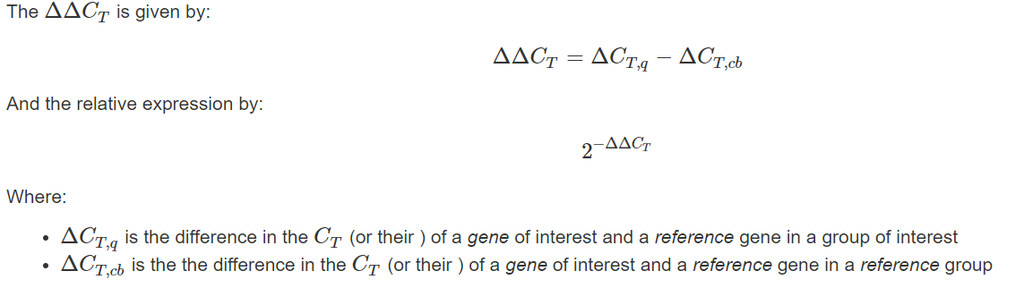

Fig5. delta_delta_Ct method

To calculate $\Delta\Delta$Ct we need to perform the folowing steps:

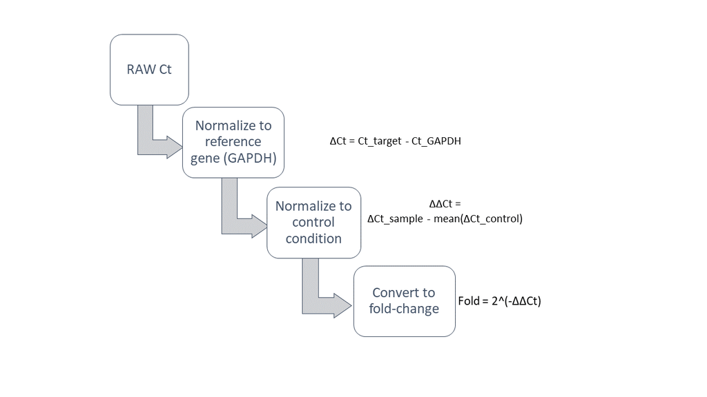

Fig6. delta_delta_Ct calculation

We will now perform the necessary steps on our tidied qPCR dataset.

```r
# ---- 4. Calculate ΔCt ----
tidy_qpcr[, delta_Ct := Target - Reference]

# ---- 5. Calculate ΔΔCt ----
mean_control_deltaCt <- tidy_qpcr[Condition == "Control", mean(delta_Ct, na.rm = TRUE)]
tidy_qpcr[, delta_delta_Ct := delta_Ct - mean_control_deltaCt]

# ---- 6. Calculate relative expression ----
tidy_qpcr[, rel_expression := 2^(-delta_delta_Ct)]

# ---- 7. Summarize per condition ----
summary_qpcr <- tidy_qpcr[, .( mean_deltaCt = mean(delta_Ct, na.rm =
TRUE), mean_rel_expression = mean(rel_expression, na.rm = TRUE) ), by =
Condition]


gt(tidy_qpcr, caption = "ΔΔCt and relative expression results")
```

ΔΔCt and relative expression results

| Sample | Condition_Time | Replicate | Target | Reference | Condition | Time | delta_Ct | delta_delta_Ct | rel_expression |
| --- | --- | --- | --- | --- | --- | --- | --- | --- | --- |
| ctrl_1 | Control_24h | 1 | 22.1 | 20.0 | Control | 24h | 2.1 | -0.2 | 1.1486984 |
| ctrl_2 | Control_24h | 1 | 23.0 | 20.2 | Control | 24h | 2.8 | 0.5 | 0.7071068 |
| ctrl3 | Control_24h | 1 | 22.0 | 19.8 | Control | 24h | 2.2 | -0.1 | 1.0717735 |
| treat1 | Treatment_24h | 1 | 18.5 | 18.0 | Treatment | 24h | 0.5 | -1.8 | 3.4822023 |
| treat_2 | Treatment_24h | 1 | 19.3 | 17.7 | Treatment | 24h | 1.6 | -0.7 | 1.6245048 |
| treat_3 | Treatment_24h | 1 | 18.9 | NA | Treatment | 24h | NA | NA | NA |
| ctrl_1 | Control_24h | 2 | 22.3 | 19.9 | Control | 24h | 2.4 | 0.1 | 0.9330330 |
| ctrl_2 | Control_24h | 2 | NA | 20.1 | Control | 24h | NA | NA | NA |
| ctrl3 | Control_24h | 2 | 21.9 | 19.9 | Control | 24h | 2.0 | -0.3 | 1.2311444 |
| treat1 | Treatment_24h | 2 | 18.4 | 18.1 | Treatment | 24h | 0.3 | -2.0 | 4.0000000 |
| treat_2 | Treatment_24h | 2 | 19.5 | NA | Treatment | 24h | NA | NA | NA |
| treat_3 | Treatment_24h | 2 | 19.0 | 17.8 | Treatment | 24h | 1.2 | -1.1 | 2.1435469 |

```r
gt(summary_qpcr, caption = "Summary results")
```

Summary results

| Condition | mean_deltaCt | mean_rel_expression |
| --- | --- | --- |
| Control | 2.3 | 1.018351 |
| Treatment | 0.9 | 2.812563 |

You can check out this [tutorial on qPCR analysis](https://cran.r-project.org/web/packages/pcr/vignettes/qpcr_analysis.html#analysis-methods) for more details.

## **Types of graphs in R**

### Graphs in R

Variable types:

- categorical :

  ```
    nominal
    ordinal
  ```

- quantitative :

  ```
    numerical discrete
    numerical continuous
  ```

Appropriate graphs depend on the number and type of variables that we are plotting.

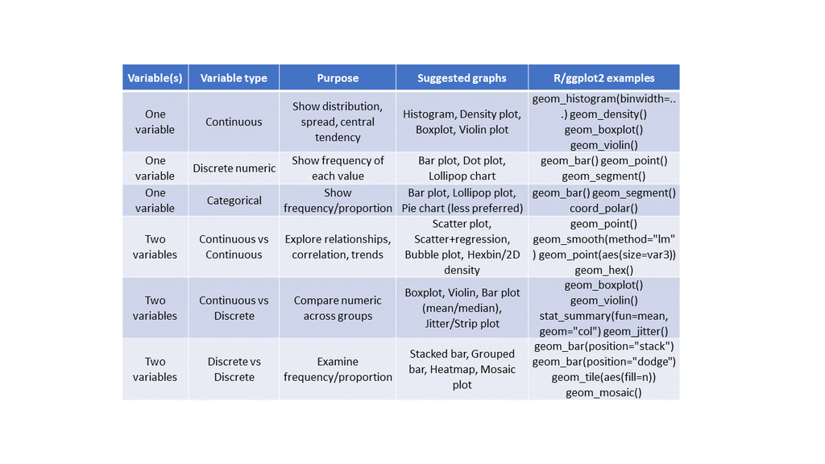

Fig7. Graphs by variable type

Let’s again simulate some data which we will use for different types of visualizations.

```r
set.seed(123)

# Simulate dataset

n_samples <- 40

df <- data.table(
  SampleID = paste0("S", 1:n_samples),
  Treatment = rep(c("Control", "Treated"), each = n_samples/2),
  CellType = sample(c("TypeA", "TypeB"), n_samples, replace = TRUE),
  Mutation = sample(c("WT", "Mut"), n_samples, replace = TRUE),
  NumMutations = sample(0:5, n_samples, replace = TRUE),
  Gene1_expr = rnorm(n_samples, mean = ifelse(rep(c("Control", "Treated"), each = n_samples/2) == "Control", 10, 12), sd = 2),
  Gene2_expr = rnorm(n_samples, mean = ifelse(rep(c("Control", "Treated"), each = n_samples/2) == "Control", 8, 9), sd = 1.5),
  Protein_expr = rnorm(n_samples, mean = ifelse(rep(c("Control", "Treated"), each = n_samples/2) == "Control", 50, 60), sd = 8)
)

gt(head(df, n= 10), caption = "Dataset for visualizations")
```

Dataset for visualizations

| SampleID | Treatment | CellType | Mutation | NumMutations | Gene1_expr | Gene2_expr | Protein_expr |
| --- | --- | --- | --- | --- | --- | --- | --- |
| S1 | Control | TypeA | WT | 5 | 11.844535 | 7.429660 | 66.80087 |
| S2 | Control | TypeA | Mut | 5 | 14.100169 | 9.378495 | 39.70376 |
| S3 | Control | TypeA | Mut | 2 | 9.017938 | 7.136980 | 56.30191 |
| S4 | Control | TypeB | WT | 5 | 5.381662 | 8.911946 | 56.15234 |
| S5 | Control | TypeA | WT | 5 | 12.011477 | 5.573176 | 52.65762 |
| S6 | Control | TypeB | WT | 0 | 8.581598 | 7.916657 | 41.93299 |
| S7 | Control | TypeB | WT | 5 | 8.623983 | 8.779111 | 49.04438 |
| S8 | Control | TypeB | Mut | 1 | 12.051143 | 8.451730 | 47.75684 |
| S9 | Control | TypeA | WT | 0 | 9.430454 | 8.158514 | 54.50392 |
| S10 | Control | TypeA | WT | 1 | 7.558565 | 7.038941 | 47.02049 |

*Categorical variables example:*

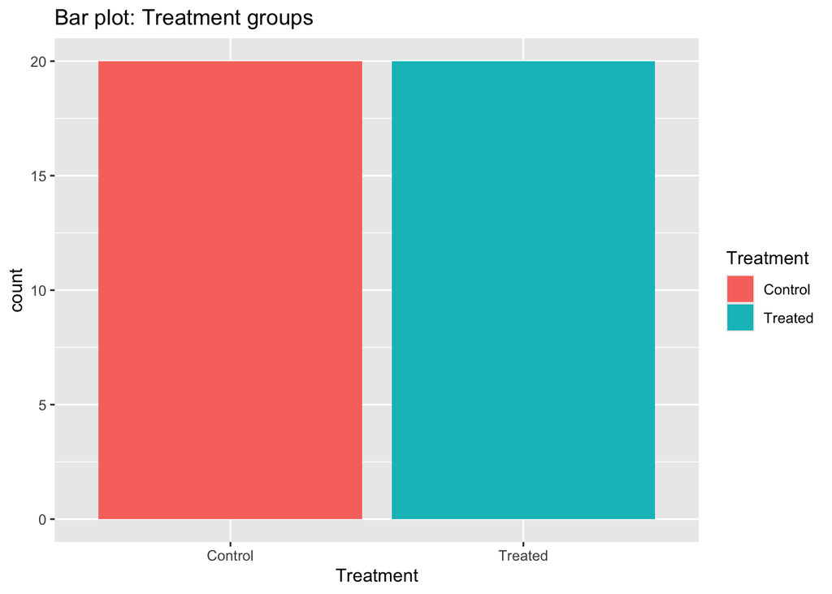

*Quantitative variables examples:*

Numerical continuous:

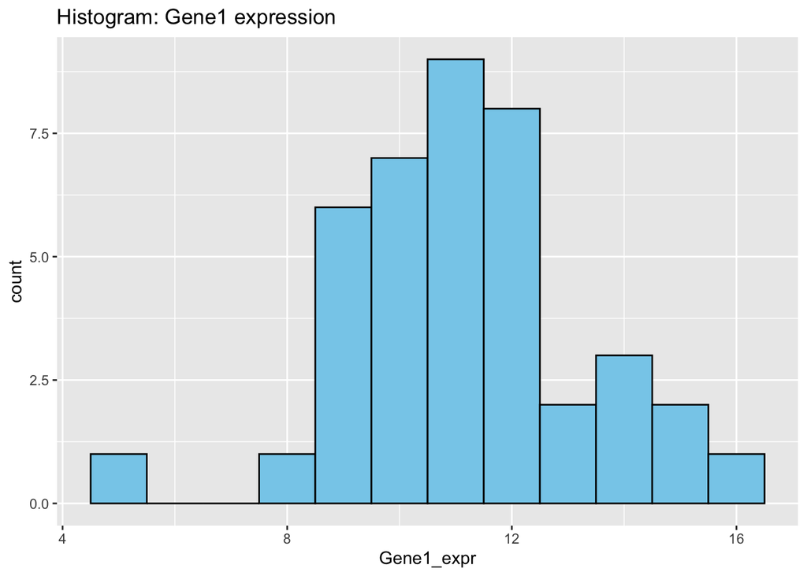

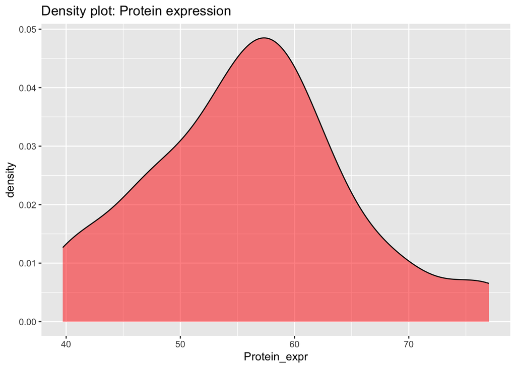

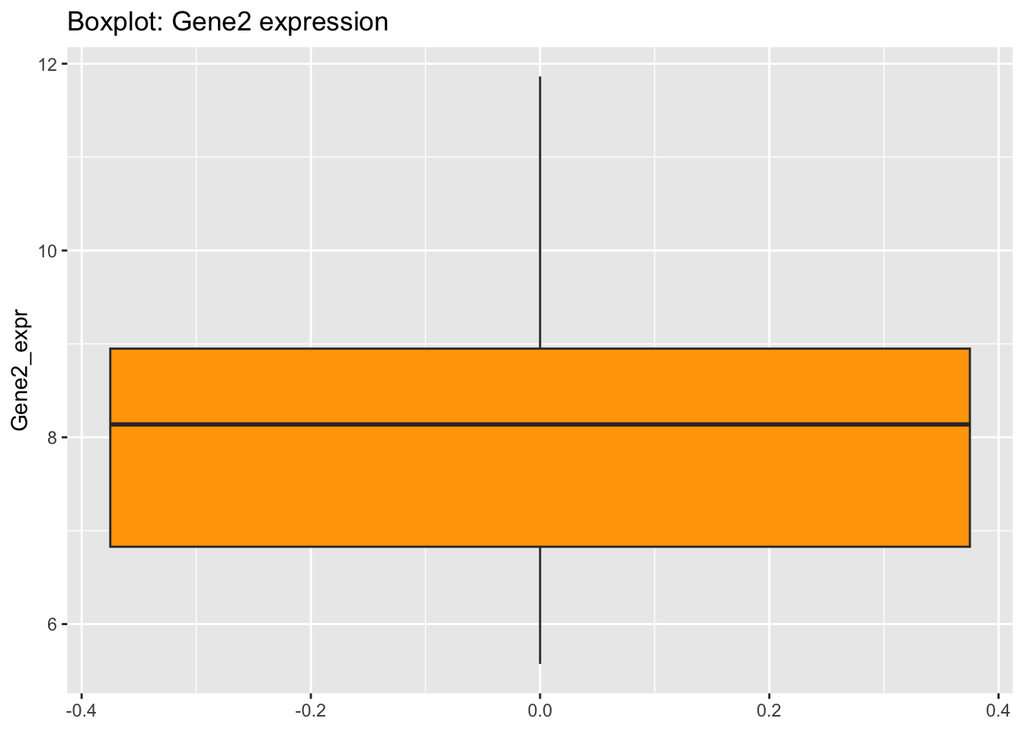

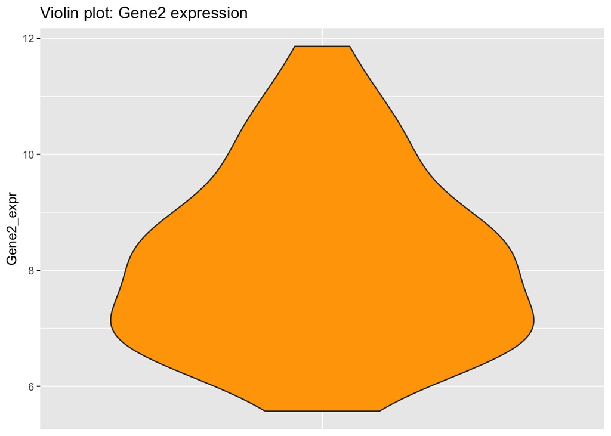

Numerical discrete:

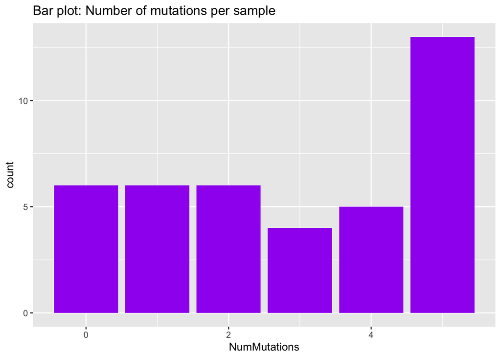

### Graphs with two variables: Continuous X, Continuous Y

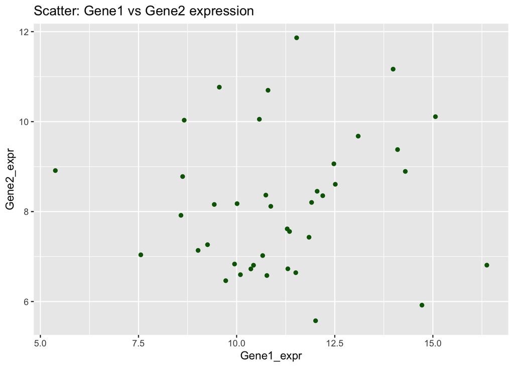

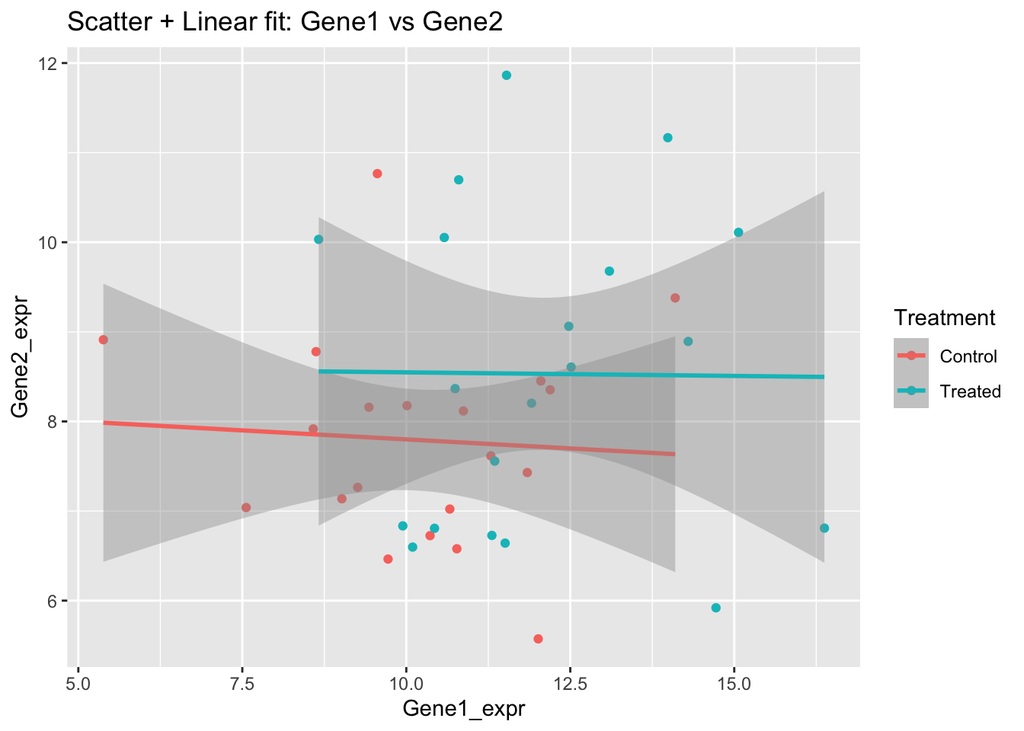

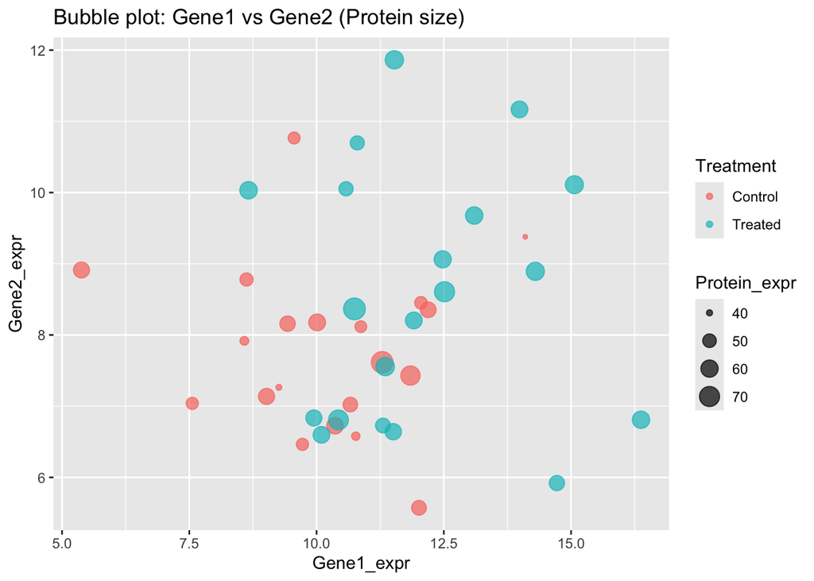

### Graphs with two variables: Discrete X, Continuous Y

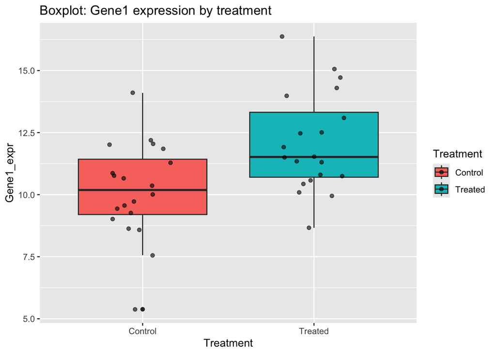

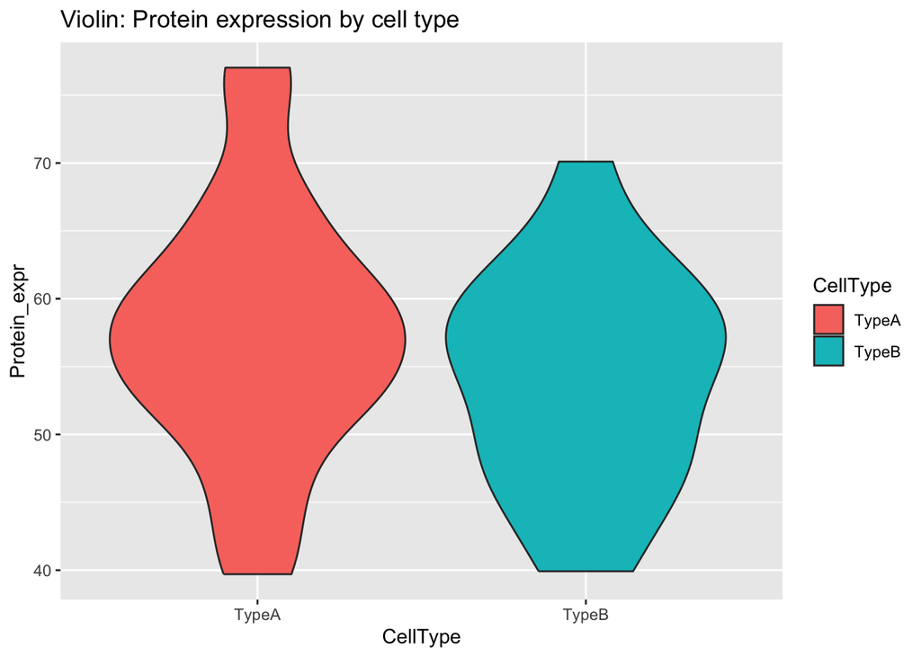

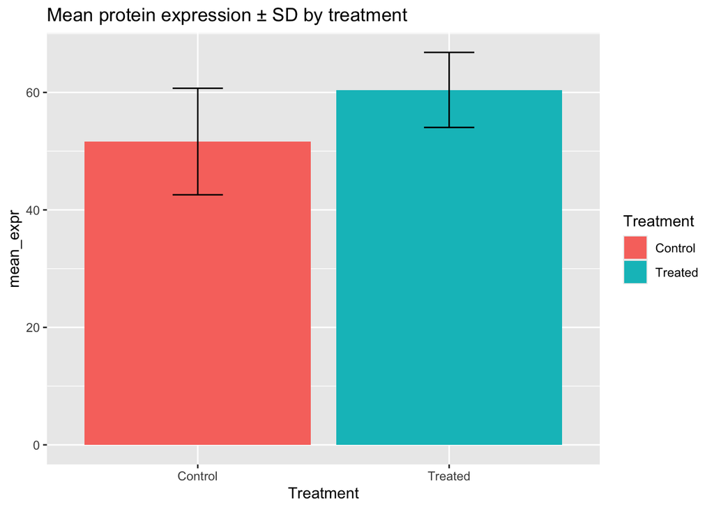

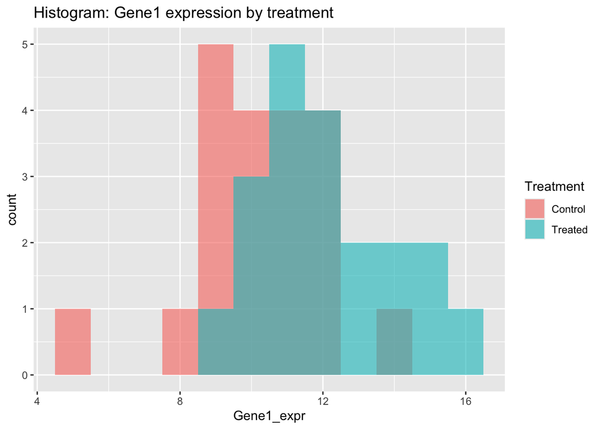

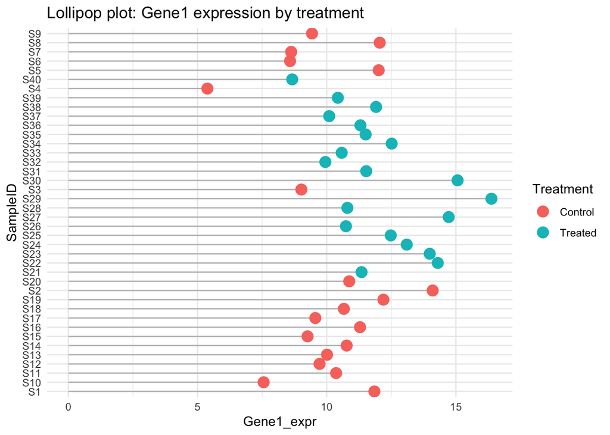

### Graphs with two variables: Discrete X, Discrete Y

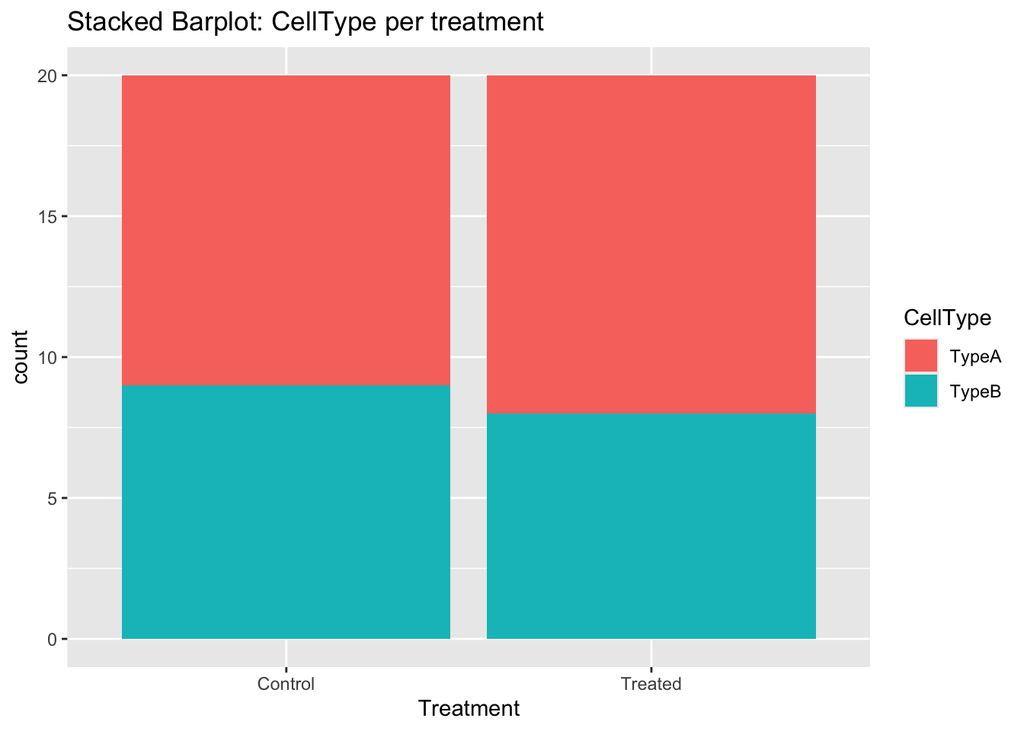

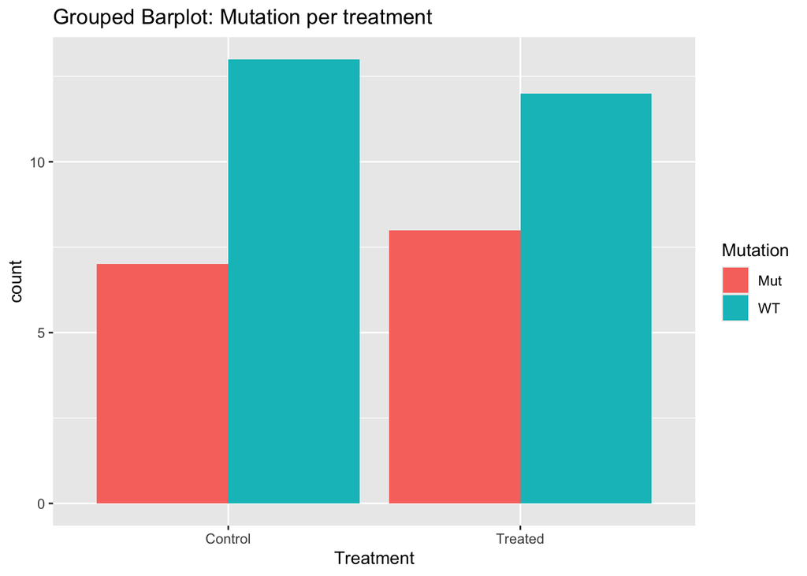

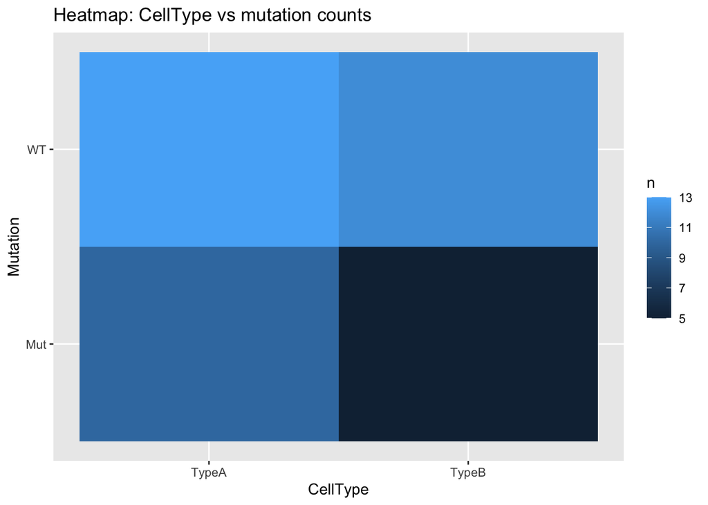

**Q2: Let’s simulate another tidy qPCR dataset. What would be the appropriate graphs for the following research questions:**

```r
set.seed(123)

genes <- c("TP53", "MYC", "GAPDH", "BRCA1")
n_samples <- 8

# Create samples data.table
samples <- data.table(
  SampleID = paste0("S", 1:n_samples),
  Condition = rep(c("Control", "Treated"), each = n_samples/2)
)

# Create qpcr_raw by expanding genes and SampleID, joining sample info, and simulating Ct values
qpcr_raw <- CJ(Gene = genes, SampleID = samples$SampleID)[
  samples, on = "SampleID"
][
  , Ct := fifelse(Gene == "TP53" & Condition == "Control", rnorm(.N, 22, 1),
           fifelse(Gene == "TP53" & Condition == "Treated", rnorm(.N, 20, 1),
           fifelse(Gene == "MYC" & Condition == "Control", rnorm(.N, 18, 1),
           fifelse(Gene == "MYC" & Condition == "Treated", rnorm(.N, 17, 1),
           fifelse(Gene == "BRCA1" & Condition == "Control", rnorm(.N, 24, 1),
           fifelse(Gene == "BRCA1" & Condition == "Treated", rnorm(.N, 22, 1),
           rnorm(.N, 15, 0.5)))))))]

# Compute deltaCt normalized to GAPDH Ct per SampleID
qpcr_dCt <- merge(
  qpcr_raw,
  qpcr_raw[Gene == "GAPDH", .(SampleID, Ct_ref = Ct)],
  by = "SampleID"
)[
  , deltaCt := Ct - Ct_ref
]

# Compute deltaDeltaCt and fold change by gene
qpcr_ddCt <- qpcr_dCt[
  , .(mean_dCt_control = mean(deltaCt[Condition == "Control"])), by = Gene
][
  qpcr_dCt, on = "Gene"
][
  , deltaDeltaCt := deltaCt - mean_dCt_control
][
  , fold_change := 2^(-deltaDeltaCt)
][
  Gene != "GAPDH"  # filter out reference gene
]



gt(qpcr_ddCt, caption = "Tidied qPCR data, example 2")
```

Tidied qPCR data, example 2

| Gene | mean_dCt_control | SampleID | Condition | Ct | Ct_ref | deltaCt | deltaDeltaCt | fold_change |
| --- | --- | --- | --- | --- | --- | --- | --- | --- |
| BRCA1 | 8.743939 | S1 | Control | 23.03814 | 14.55232 | 8.485825 | -0.2581137 | 1.1959140 |
| MYC | 3.026427 | S1 | Control | 18.44821 | 14.55232 | 3.895891 | 0.8694645 | 0.5473500 |
| TP53 | 7.401852 | S1 | Control | 22.07051 | 14.55232 | 7.518190 | 0.1163380 | 0.9225264 |
| BRCA1 | 8.743939 | S2 | Control | 24.04123 | 14.37436 | 9.666869 | 0.9229299 | 0.5274368 |
| MYC | 3.026427 | S2 | Control | 17.50897 | 14.37436 | 3.134605 | 0.1081776 | 0.9277593 |
| TP53 | 7.401852 | S2 | Control | 20.73494 | 14.37436 | 6.360574 | -1.0412777 | 2.0580495 |
| BRCA1 | 8.743939 | S3 | Control | 22.53936 | 15.65621 | 6.883153 | -1.8607853 | 3.6320531 |
| MYC | 3.026427 | S3 | Control | 17.31199 | 15.65621 | 1.655785 | -1.3706421 | 2.5858562 |
| TP53 | 7.401852 | S3 | Control | 22.35981 | 15.65621 | 6.703607 | -0.6982448 | 1.6225296 |
| BRCA1 | 8.743939 | S4 | Control | 24.70178 | 14.76188 | 9.939908 | 1.1959691 | 0.4364932 |
| MYC | 3.026427 | S4 | Control | 18.18130 | 14.76188 | 3.419427 | 0.3930000 | 0.7615444 |
| TP53 | 7.401852 | S4 | Control | 23.78691 | 14.76188 | 9.025037 | 1.6231845 | 0.3246181 |
| BRCA1 | 8.743939 | S5 | Treated | 22.03779 | 14.97299 | 7.064802 | -1.6791363 | 3.2023617 |
| MYC | 3.026427 | S5 | Treated | 17.51941 | 14.97299 | 2.546421 | -0.4800057 | 1.3947492 |
| TP53 | 7.401852 | S5 | Treated | 19.97145 | 14.97299 | 4.998467 | -2.4033848 | 5.2904293 |
| BRCA1 | 8.743939 | S6 | Treated | 20.93667 | 14.74197 | 6.194706 | -2.5492329 | 5.8532299 |
| MYC | 3.026427 | S6 | Treated | 16.15030 | 14.74197 | 1.408328 | -1.6180994 | 3.0697036 |
| TP53 | 7.401852 | S6 | Treated | 21.51647 | 14.74197 | 6.774503 | -0.6273496 | 1.5447245 |
| BRCA1 | 8.743939 | S7 | Treated | 21.76372 | 14.63847 | 7.125253 | -1.6186853 | 3.0709506 |
| MYC | 3.026427 | S7 | Treated | 16.50944 | 14.63847 | 1.870976 | -1.1554514 | 2.2275401 |
| TP53 | 7.401852 | S7 | Treated | 20.21594 | 14.63847 | 5.577475 | -1.8243776 | 3.5415418 |
| BRCA1 | 8.743939 | S8 | Treated | 22.75405 | 15.30899 | 7.445061 | -1.2988778 | 2.4603744 |
| MYC | 3.026427 | S8 | Treated | 17.23539 | 15.30899 | 1.926394 | -1.1000333 | 2.1435964 |
| TP53 | 7.401852 | S8 | Treated | 18.98142 | 15.30899 | 3.672432 | -3.7294204 | 13.2637830 |

1. Comparison of TP53 and MYC expression
2. Comparison of ΔCt values across control and treated samples
3. Average relative gene expression per treatment group
4. Value of deltaDeltaCt by sample and gene

### ggplot2 vs. base R plots

plot() - generic function in base R (type of plot depends on the type/class of the first argument)

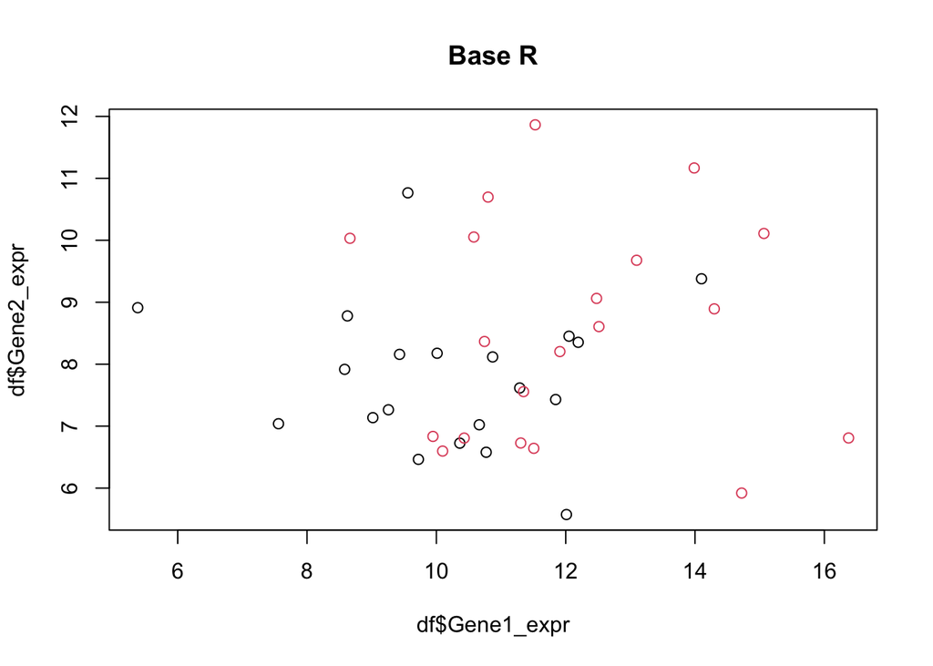

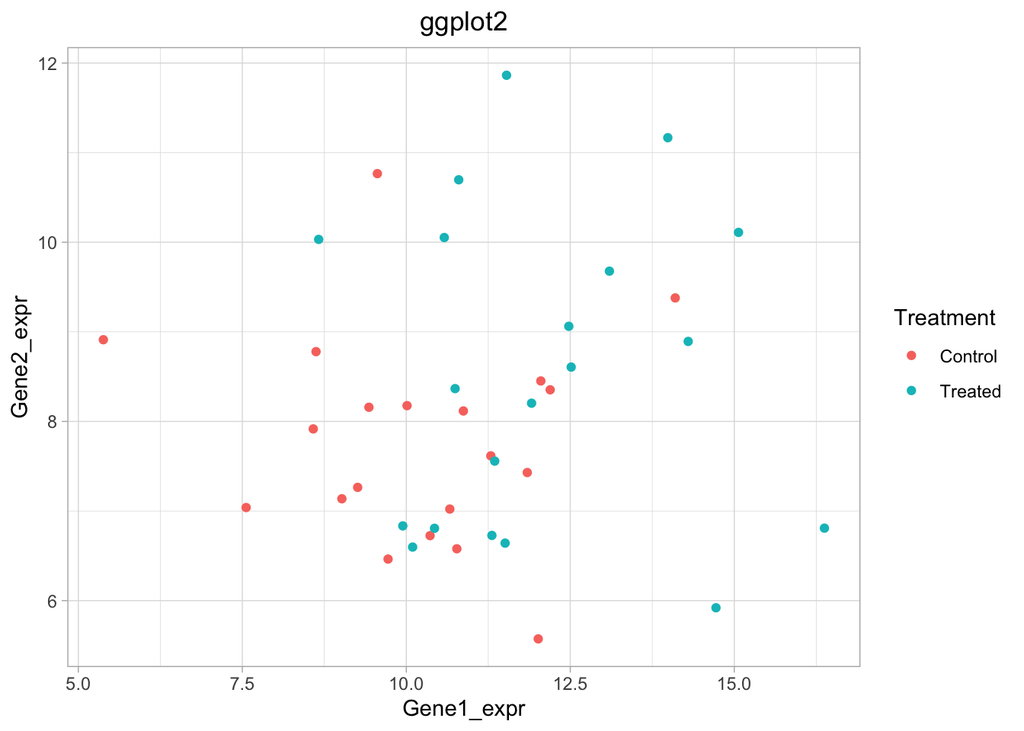

Check out [ggplot cheat sheet](https://rstudio.github.io/cheatsheets/data-visualization.pdf) to see which type of plot fits your kind of data.

## **Basics of ggplot2**

### Basic ggplot logic: ggplot(data, aes(x,y))

The ggplot() object acts as a storage facility for the data. It is here where we define the data frame that houses the x and y coordinate values themselves and instructions on how to split the data. There are three ways to initialise a ggplot() object:

`p <- ggplot()`

`p <- ggplot(data_frame)`

`p <- ggplot(data_frame, aes(x, y))`

### Mapping aesthetics to data

The aes() aesthetic mapping function lives inside a ggplot object and is where we specify the set of plot attributes (x and y axis, color) that remain constant throughout the subsequent layers (unless overwritten, more on this later).

We can consider the relationship between the aes() and geoms components as follows:

The aes() function is *how* data is stored, how data is split, and geoms is *what* the data looks like. These are geometrical objects stored in subsequent layers.

### Layers

We use the + operator to construct. By appending layers we can connect the “how” (aesthetics) to the “what” (geometric objects). Adding geometric, scale, facet and statistic layers to a ggplot() object is how to control virtually every visual aspect of the plot from the data contained in the object.

### Adding a geometric object layer

A geometric object is used to define the style of the plot. Common geometric objects include:

geom_point() which is used to draw a dot plot  
geom_line() used to draw a line plot  
geom_bar() or geom_col() used to draw a bar chart  
`geom_bar()` counts the number of observations in  
each category automatically. `geom_col()` uses values that have already been calculated and supplied in the dataset.

Available graphs can be seen at [R graph gallery](https://www.r-graph-gallery.com/ggplot2-package.html)

### Facets

Appending a facet layer to a ggplot generates the same plot for different subsets of data.

### Statistics

Exploratory data analysis can be done using the base packages in R, the results of which can be added to a ggplot() in the guise of a geom layer.

### Data for examples

In this lecture we will be using microarray expression data for 2 microarray probes measured in leukemia patients with different cancer stages. The data is available at http://hex.bioinfo.hr/~rosa/R_workshop/1242_at.leukemia.txt and http://hex.bioinfo.hr/~rosa/R_workshop/1866_g_at.leukemia.txt

```r
# read in the data for the 1242_at probe expression levels

data <- read.delim("http://hex.bioinfo.hr/~rosa/R_workshop/1242_at.leukemia.txt");data
```

|  | expression | stage |
| --- | --- | --- |
| 01005 | 6.594910 | B2 |
| 01010 | 6.564573 | B2 |
| 04006 | 6.696147 | B1 |
| 04007 | 6.321552 | B2 |
| 04008 | 6.588449 | B1 |
| 04010 | 6.853832 | B1 |
| 04016 | 6.370895 | B1 |
| 06002 | 6.441823 | B2 |
| 08001 | 6.227591 | B2 |
| 08011 | 6.675492 | B3 |

[output cut: 68 more lines]

### Example: basic layout

- x axis is categorical, y axis is numerical

Set the basic layout:

- We want to analyze the 1242_at probe and visualize the differences of expression across stages. Produce a layout in which the x axis represents the stage and the y axis represents expression of the 1242_at probe.

```r
# read in the data for the 1242_at probe expression levels

data <- read.delim("http://hex.bioinfo.hr/~rosa/R_workshop/1242_at.leukemia.txt")
```

**Hint:** You need to tell ggplot what your data is and define the aesthetics.

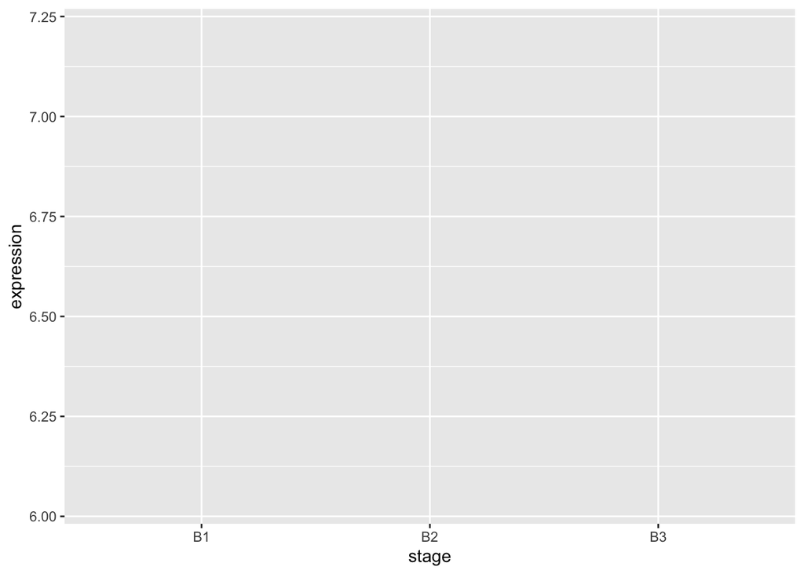

```r
# create a layout in which x axis to represent stage and y to represent expression

p <- ggplot(data, aes(x = stage, y = expression))
p
```

### Example: add a layer - graph type

Choose the graph type that you want to show. Lets say we want a scatterplot of 1242_at expression values for each stage. Add geom_point() to your layout.

**Hint:** We need to define data and aesthetics and add layers to the existing plot using “+”.

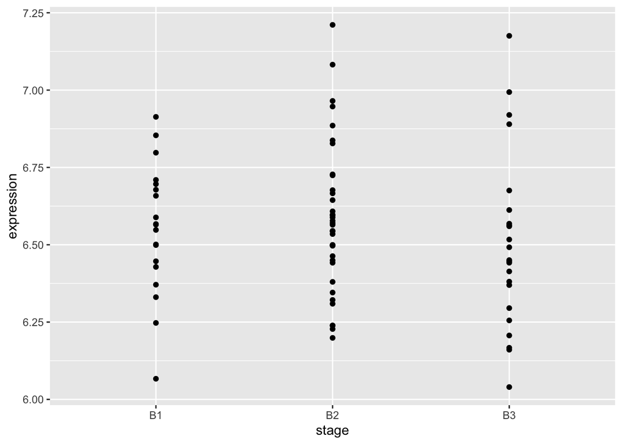

```r
# add points to your plot

p <- ggplot(data, aes(x = stage, y = expression)) + geom_point()
p
```

### Example: modifying the graph with aesthetics

Aesthetics can be defined inside the ggplot() call or inside individual layers. Color the points by stage. Do this inside geom_point.

```r
# color the points by stage
```

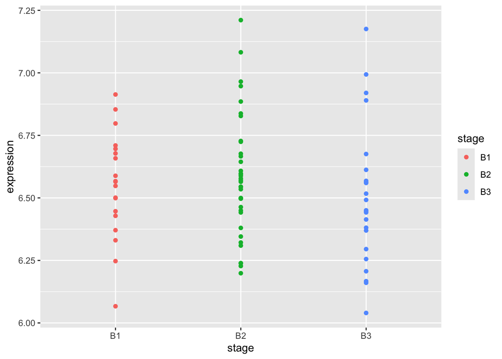

```r
p <- ggplot(data, aes(x = stage, y = expression)) + geom_point(aes(color = stage))
p
```

### Example: add another layer (boxplot)

We wanted a scatterplot but changed out mind and now we also want boxplot on top of this scatterplot. Add + geom_boxplot() to the previous line to see what you get.

**Hint:** Layers are added using “+”.

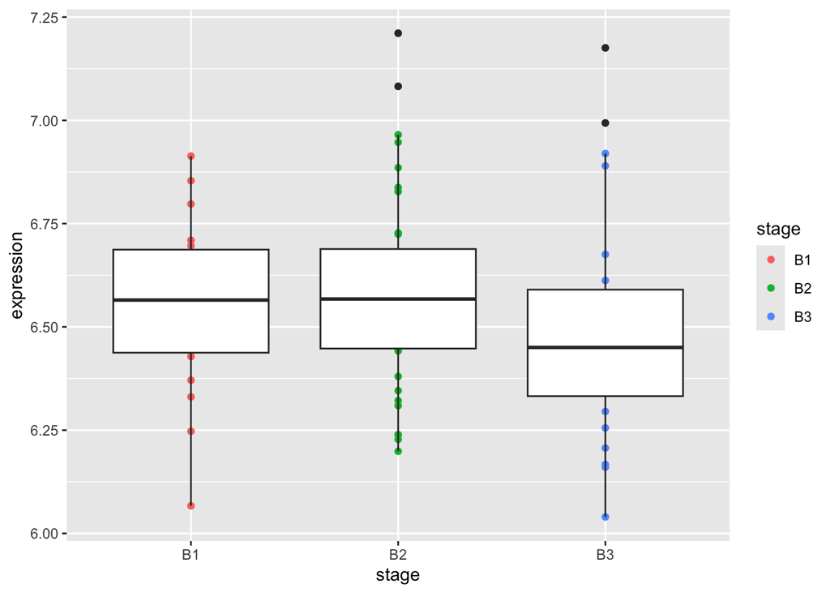

```r
# add a boxplot layer

p <- ggplot(data, aes(x = stage, y = expression)) + geom_point(aes(color = stage)) + geom_boxplot()
p
```

There are also color palettes such as viridis palette designed to be perceived by viewers with common forms of color blindness.

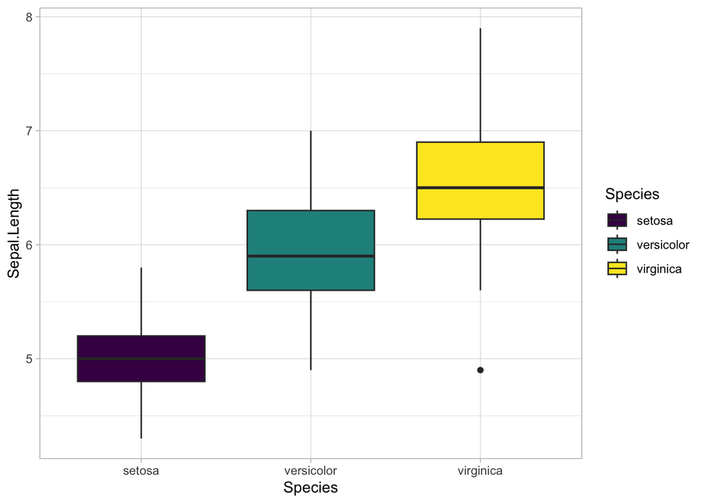

```r
p <- ggplot(iris, aes(x=Species, y=Sepal.Length, fill= Species)) +
  geom_boxplot() +
  scale_fill_viridis_d()+
  theme_light()
p
```

### Example: Setting aesthetics

The *aes()* function in ggplot2 maps data variables to visual properties (aesthetics) and can be specified: - inside *ggplot()* to apply globally - inside individual layers to apply locally - set outside *aes()* to apply a constant value rather than a mapped variable

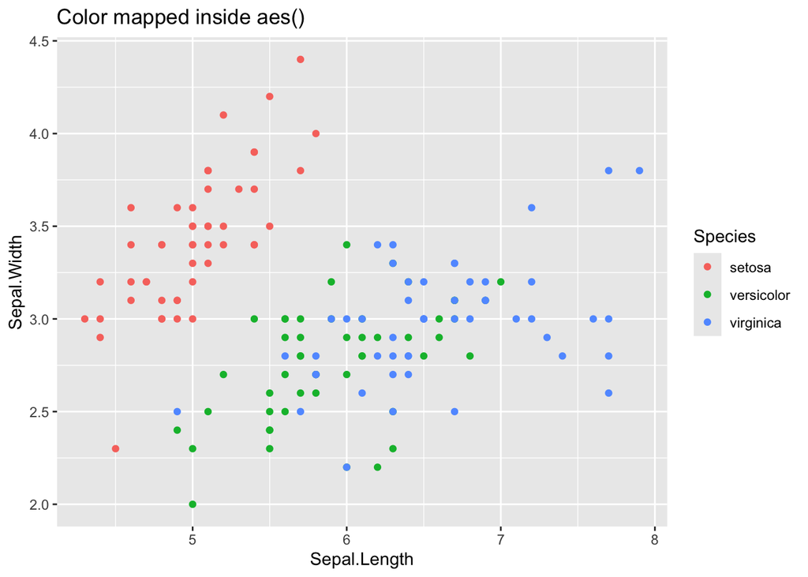

```r
# 1. Aesthetics mapped inside aes(): color mapped to Species (varies by data)
p1 <- ggplot(iris, aes(x = Sepal.Length, y = Sepal.Width, color = Species)) +
  geom_point() +
  ggtitle("Color mapped inside aes()")
p1
```

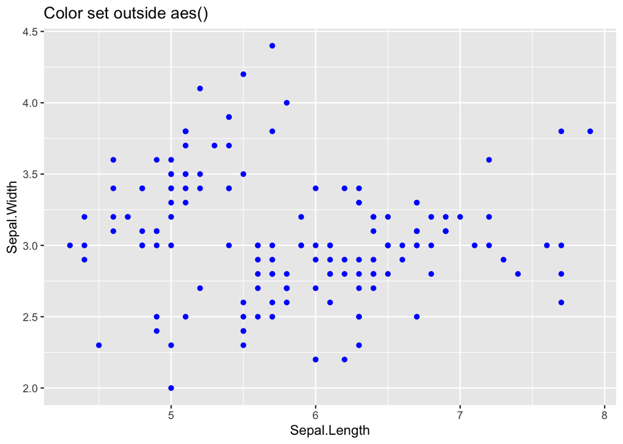

```r
# 2. Aesthetics set outside aes(): color fixed to blue for all points
p2 <- ggplot(iris, aes(x = Sepal.Length, y = Sepal.Width)) +
  geom_point(color = "blue") +
  ggtitle("Color set outside aes()")
p2
```

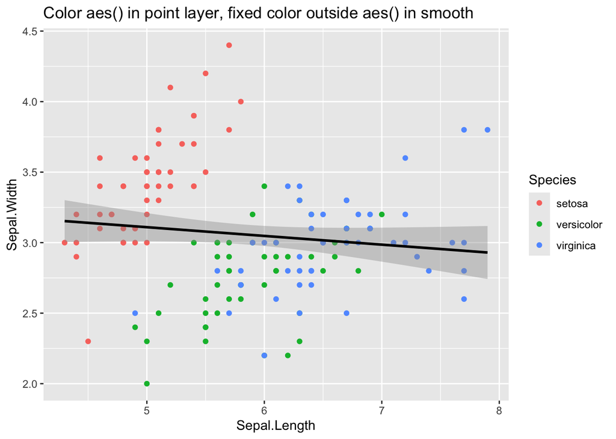

```r
# 3. Aesthetics mapped inside aes() globally, and overridden or added in layer's aes():
p3 <- ggplot(iris, aes(x = Sepal.Length, y = Sepal.Width)) +
  geom_point(aes(color = Species)) +   # color mapped per Species, local layer aes()
  geom_smooth(method = "lm", color = "black") +  # smooth line fixed black color, outside aes()
  ggtitle("Color aes() in point layer, fixed color outside aes() in smooth")
p3
```